# Predicting Mutual Fund Performance Worldwide using Supervised Machine Learning

### VHB ProDok Seminar in Machine Learning - Fall 2023

#### Submitted by Manuel Mazidi*

###### Declaration I, Manuel Mazidi, hereby declare that the work presented in this research project is entirely my own, unless stated otherwise. All ideas, data, code and other information taken from external sources have been duly acknowledged and referenced. In the course of this project, I have made use of AI tools, including Perplexity AI and Chat GPT, primarily for coding purposes and to enhance code efficiency. These tools have been instrumental in assisting with the development and optimization of the code used in this research, but the final decisions and implementations are my own. I have never used any AI tool for any other text generation process except for code and I have never used any AI tool for the interpretation of results and/or implications thereof.

*University of Neuchâtel, manuel.mazidi@unine.ch

## Overview and Table of Contents

This Jupyter Notebook is submitted for the assignment task of the VHB ProDok Seminar in Machine Learning which took place in October 2023. The purpose of this Notebook is to demonstrate the ability to apply Machine Learning (ML) tools in a research context.

In the following project, I will cover various supervised ML models in the research field of mutual funds and their performance. With this, I hope to contribute to the ongoing discussion if there is predictablity in mutual fund performance when using primarily mutual fund characteristics in a cross-sectional setting and international mutual fund dataset.

## 1. Introduction

Mutual funds have emerged as one of the most important investment instruments for institutional investors and private households. These funds invest and manage a significant part of the capital of insurance companies, pension funds, but also private wealth management. According to the [Investment Company Fact Book](https://www.icifactbook.org/pdf/2023-factbook-ch1.pdf), regulated funds managed \$60.1 trillion in net assets globally at the end of 2022, while \$27 trillion was invested in equity funds. Better investment decisions through an enhanced fund selection process can play a crucial role in improving the financial health of insurers and pension funds, which are under pressure due to demographic changes in an ageing society. However, with around 46'000 equity funds available globally competing for capital, a systematic fund selection process can be difficult and it can be questioned whether it guarantees any advantage.

Weather predicting mutual fund performance is feasable has been tackled by researchers for decades. In a seminal work, Carhart (1997) found that after controlling for the market return, size, book-to-market and momentrum factors (the Carhart-four-factor model), mutual fund performance is not persistent beyond a one-year horizon. Yet, empirically, we observe capital inflows in funds with high past performance and outflows from underperforming funds. Berk and Green (2004) propose a theoretical model that reconciles this behaviour with the results from Carhart (1997): Rational investors allocate capital to superior performing funds and compete with eachother in identifying heterogenous managerial skills. However, with this, investors diminish the expected outperformance of funds as Berk and Green assume decreasing returns with increasing scale of operations. This can (partly) be explained by higher costs for better performing funds (see Berk and Van Binsbergen (2015)) and higher price impact and execution costs for larger actively managed portfolios (Berk and Green (2004)), leaving a net alpha close to zero for investors.

The fact that mutual fund performance is not persistent does not imply that actively managed portfolios cannot outpeform. In fact, results regarding the benefits of investing in actively managed funds is wiedely discussed: Kacperczyk, Nieuwerburgh, and Veldkamp (2014) (and subsequently Kacperczyk, Van Nieuwerburgh, and Veldkamp (2016)) find evidence that a fraction of fund managers realize excess returns while Berk and Van Binsbergen (2015) and Fama and French (2010) find little evidence that a small fraction of fund managers generate positive alphas after costs.

If we indeed assume that positive net alpha can be realized by the most successful funds, how can we identify them if research tells us that persistency in mutual fund performance does not exist? While classical econometric methods did not allow for forecasting future fund perromance, the advent of machine learning models in the last decade equipped researches with new tools to tackle the question if mutual fund performance can be anticipated.

### 1.1 Machine Learning and Mutual Fund Selection

Gu, Kelly, and Xiu (2020) use the following arguments on why machine learning should be considered for the prediction of fund performance:

1. Many machine learning models are powerful with a large set of predictors which more traditional methods could not handle well.
2. A bigger set of predictors increases the risk of multicolinearity. Yet, some machine learning methods exhibit regularization techniques which can handle such highly correlated datasets well.
3. Traditional econometrics and asset pricing require a thorough understanding of the functional form of the used models. It is difficult to asses if different factors relate to eachother linearly or if even non-linearities are present. Furhtermore, it is often unclear which interactions of variables should enter the model and where. Machine learning models can well handle non-linearities and models such as neural networks neural networks are powerful universal "approximators" of underlying relationships which is why it is not required to assume an explicit functional form of the model.

In the last few years, several researchers studied the use of machine learning for fund selection and publisehd promising results. In the following, I review some important research articles. The list is of mentioned articles is not exhaustive for the area of machine learning applications in empirical asset pricing and mutual fund research but I consider the following works to be most relevant for the subsequent study.

Kaniel et al. (2022) conclude that machine learning models can distinguish between high and low-performing mutual funds. Furthermore, they find that this differentiation is possible by using fund charactersitics only while information on stock holdings is not predictive for future performance. In a similar work, DeMiguel et al. (2021) also find that machine learning applied to fund characteristics helps to construct efficient long-only portfolios with economically large positive alphas net of costs. Wu et al. (2021) also apply machine learning models in the cross-section for fund selection. However, as opposed to the afformentioned works, they focus on hedge funds instead of open-end mutual equity funds. Nevertheless, they conclude that cross-sectional forecast based on fund specific information outperforms forecasts using time series regression.

Li and Rossi (2020) focus on mutual funds' hodlings and stock characteristics (exposure to factors) and find that especially boosted regression trees are a powerful tool for detecting significant performance predictability, yet, these predictability is time varying. Chu et al. (2022) focus on deep learning models and apply these in a time series framework as opposed to the cross-sectional approaches used in the afformentioned articles. They conlcude that deep learning models that exhibit $memory$ are superior in forecast accuracy than more traditonal statistical methods.

### 1.2 Mutual Fund Selection with a Global Perspective

From the last paragraphs, it is clear that the application of machine learning in mutual fund research has already attracted a lot of attention and led to a fruitful research thread. Yet, all the above mentioned articles cover only the mutual fund universe in the United States. In fact, most of these articles use the mutual fund data from CRSP which seems to exhibit good quality, however, it neglects the fund industry outside the US. In his study, I would like to focus on a global dataset to see what implications I can derive for a more general and global perspective on the mutual fund industry. For this, I use a large dataset from the research firm Moringstar that collects data on mutual funds globally. In terms of methodology, I will stick very cloesly to the approaches in Kaniel et al. (2022), DeMiguel et al. (2021) and Wu et al. (2021). That is, I will apply their proposed machine learning models on the cross-section of several mutual fund characteristics and neglect the actual stocks they hold.

With this study, I would like to contribute to several (potentially) interesting research questions that can be adressed using a global dataset:

- Are non-US funds easier to predict because of less market efficiency?
- Are there any differences in the importance of features across regions?
- Understanding fund performance: Can I confirm the findings of Berk and Van Binsbergen (2015) such that funds with highly predicted performances are on average also more costly? Does this relationship hold worldwide?
- Does our international data help to improve performance forecasting for US funds? Meaning, are there any flight-to-quality / flight-to-safety mechanisms that our models might pick up?
- Maybe the machine learning predictability in the US disappears over time due to the already extensive coverage in research, but not internationally? This seems to be the case for equities. How does it look like for mutual funds?
- Smart vs. dumb money discussion: Funds with higher inflows underperform in the future. Are US investors ”smarter”?

## 2. Data Description

In this section, I explain the data which was used in this study. The data for every supervised machine learnin task can be dissected into a set of feature varialbes (which serve as explanatory variables) and target data which which we try to classify or predict.

Taking the analogy of a regression task, the feature variables relate to the independent variables `X` while the target is the dependent variable `y`. Throughout this study, I use the terms *features*, *predictors* and *explanatory variables* synonymously and abbreviate it with `X` while I use primarily the term *target* for the dependent variable `y`.

Almost all data was downloaded from [Morningstar](https://www.morningstar.ch/ch/) (in the following abbreviated with MS) with the exception of factor returns which are used for the regression stated below in equation (1). Factor returns for all available geographic regions were downloaded from Kenneth French's [website](https://mba.tuck.dartmouth.edu/pages/faculty/ken.french/data_library.html). In order to calculate excess returns, I gathered interest rate data from the [Federal Reserve Bank of St.Louis](https://fred.stlouisfed.org/). The data used in this study is of monthly frequency and covers the period between January 1980 to end of July 2022. The number of mutual funds grows rapidly and cumulates in 2008 with roughly 14'000 of funds available per month. At the end of the sample in 2022, there were still around 10'000 mutual funds available per month. The data consists of 3'643'192 month-fund-rows.

The use of an international dataset requires adequate interest rate levels across the globe for the sample period as the calculation of excess returns plays a crucial role in this study. Finding risk-free rates for all individual countries would have been rather difficult. While there exist some useful resources, data availability will be scarce for many emerging countries and the decisions of what rates to use as the risk-free rate can be challenged. Therefore, I resort to the data provided by Kennth French and use an aggregated geographic approach in this study. This ensures that the later calculation of realized alpha using a five-factor model + momentum is consistent. On Kenneth French's [website](https://mba.tuck.dartmouth.edu/pages/faculty/ken.french/data_library.html), he provides data for the following regions:

- USA
- North America (used only for Canada)
- (Western) Europe
- Asia Pacific (excluding Japan)
- Japan
- Emerging Countries

Resulting from this, I used the same interest rates for each country within a specific region to construct excess returns or benchmark return with the relevant market returns. For this, I used the following approach: MS provides information on the (geographic) asset allocation of a fund. While this is not available for all funds over each month, I assumed that most funds have rather stable geographic asset allocations as mutual funds usually focus on some specific industry, country/region and firm size. Cross-checking the raw data revealed that indeed most funds have very stable geographic asset allocation. Then, I took the average allocation of a mutual fund for which I then constructed the excess return and market return. Put in an example, assume the following: A specific fund invests on average 70% in the US and 30% in Europe. The excess return used in this study is the difference between the fund's monthly total return minus the *risk-free* rate. For this fund, I would then construct a weighted risk-free rate which consists 70% of the US risk-free rate and 30% of the Europe's rate. The market rate was constructed in the same way.

Unfortunately, Kenneth French uses the US risk-free rate for all regions. The same is true for the [data](https://www.aqr.com/Insights/Datasets/Betting-Against-Beta-Equity-Factors-Monthly) provided by Frazzini and Pedersen (2014). Therefore, I used the following interest rate data from the [Federal Reserve Bank of St.Louis](https://fred.stlouisfed.org/):

- For the US and Canada: US Long-Term Government Bond Yields - 10-year
- For Europe: Long-Term Government Bond Yields for the Euro Area (19 Countries) - 10-Year
- For Japan: Long-Term Government Bond Yields - 10-year
- For Asia Pacific: Long-Term Government Bond Yields for Australia - 10-Year

It is not straightforward what a correct or adequate proxy for a basket of emerging countries would be. I orientated myslef on the asset allocation provided by the MSCI emerging market index in [this document](https://www.msci.com/documents/10199/1493b63f-1ce8-418e-a82d-4aae72951f27).

- Emerging Countries: Constitutes are different emerging countries weighted differently
  - From October 2000 to November 2011:
    - 40% China: 3-Month or 90-Day Rates and Yields on Treasury Securities
    - 30% South Korea: Long-Term Government Bond Yields - 10-year
    - 10% South Africa: Long-Term Government Bond Yields - 10-year
    - 10% Russia: 3-Month or 90-Day Rates and Yields on Treasury Bills
    - 5% Brazil: 3-Month or 90-Day Rates and Yields on Treasury Bills
    - 5% Mexico: Long-Term Government Bond Yields - 10-year
  - From December 2011 throuout July 2022:
    - 30% China: 3-Month or 90-Day Rates and Yields on Treasury Securities
    - 25% South Korea: Long-Term Government Bond Yields - 10-year
    - 15% India: Long-Term Government Bond Yields - 10-year
    - 7.5% South Africa: Long-Term Government Bond Yields - 10-year
    - 7.5% Russia: 3-Month or 90-Day Rates and Yields on Treasury Bills
    - 7.5% Brazil: 3-Month or 90-Day Rates and Yields on Treasury Bills
    - 7.5% Mexico: Long-Term Government Bond Yields - 10-year

The following image displays the number of funds which have their domicile in the respective country. We can see that a significant proportion of funds are still in the US. Yet, the number of funds in Europe surpasses the number of US funds.

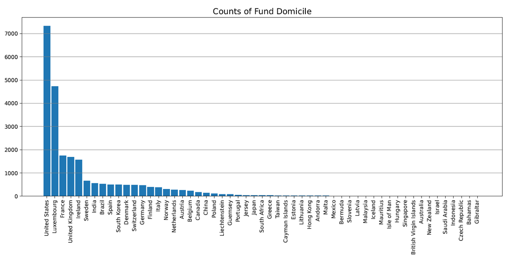

```python
from IPython.display import Image
Image("C:/Users/manue/switchdrive/Mutual Funds Project/Presentations/imgs/fund_domiciles.png", width = 1000)
```

The next chart displays the counts of countries in which fund’s position on average exceeds 50%. E.g., roughly 7000 funds invest at least 50% in the US. If no country position exhibits an allocation that exceeds 50%, then these funds are counted as *diversified*. Many mutual funds invest across countries as we can tell by the large proportion of diversified funds. The US seems to be the largest market in which mutual funds globally invest in.

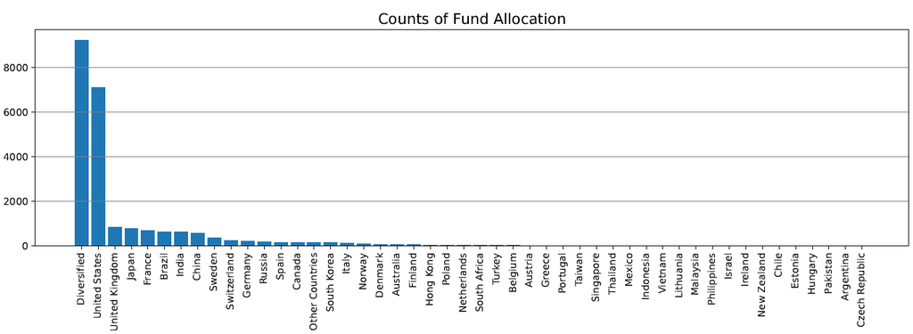

```python
Image("C:/Users/manue/switchdrive/Mutual Funds Project/Presentations/imgs/fund_allocations.png", width = 1000)
```

### 2.1 Predictor Variables

The following three tables display the set of predictors used for the main results in this study. The data source is almost exclusively MS unless explicitly stated otherwise. Summarized, I used all (or most) predictors used in Kaniel et al. (2022), DeMiguel et al. (2021) and Wu et al. (2021) to create a union of their explanatory variables.

[output not shown]

[output not shown]

Additionally, there are multiple *family* predictor variables that I included analogous to Kaniel et al. (2022). In their paper, they argue that familiy variables can carry predicitve signals as individual funds profit from information and knowledge networks across families. Furthermore, one could assume that profitable families also provide the same efficient trading infrastructure to all their funds. The *family* variables are derived from MS's `Branding Name` column. E.g., all funds from Deutsche Bank Asset and Wealth Management exhibit the branding name "Deutsche Bank". With this, all familiy variables are then calculated on an aggregate level grouped according to this branding name. The family varialbes are:

[output not shown]

Lastly, I included several variables that are the results from a rolling-window regression. All of these variables were used as predictors in the work of DeMiguel et al. (2021). Analogous to their approach, I used a five-factor model + momentum for the rolling-window regression. The regression for each month $t$ for fund $i$ is according to equation (2) in the cited articel above

\begin{align} r_{i,t}=\beta_0+\hat{\beta}_{MKT,i,t}MKT_t+ \hat{\beta}_{SMB,i,t}SMB_t+ \hat{\beta}_{HML,i,t}HML_t+ \hat{\beta}_{RMW,i,t}RMW_t+ \hat{\beta}_{CMW,i,t}CMW_t+ \hat{\beta}_{MOM,i,t}MOM_t\tag{1}\label{eq1} \end{align}

where $r_{i,t}$ is the excess return above the risk-free rate for fund $i$ at time $t$<sup>1</sup>. As a proxy for the risk-free rate, I used data availabe from the [Federal Reserve Bank of St.Louis](https://fred.stlouisfed.org/). The factor returns used in the regression come from Kenneth French's [website](https://mba.tuck.dartmouth.edu/pages/faculty/ken.french/data_library.html). I included 36 months of data for each regression. These regression related predictor variables are summarized in the following table:

[output not shown]

[output not shown]

DeMiguel et al. (2021) explain that they use t-statistics instead of raw alpha and beta coefficients to account for estimation errors<sup>2</sup>. The standard errors of the regression above are are calculated using HAC with lags up to 2. I used the proposed formula for the Bartlett kernel proposed in Newey and West (1994) for the lag selection.

1: *To be precise, the extracted variables from the rolling-window regression that are used as predictors at month $t$ come from the regression of the 36 **previous** months' excess returns and factor returns (and, hence, do not take into account the factors and excess return of month $t$. This is the same procedure as explained in DeMiguel et al. (2021). The reason for this is explained below in the target variable section where I describe the role of the *realized alpha*.*↩

2: *For more details of behind the idea of using t-statistics and mutual fund performance attribution, I refer to the original work of Hunter et al. (2014).*↩

### 2.2 Target Variables

How do we evaluate the perfromance of a mutual fund? A first approach would be simply going for the funds that realized the highest excess returns and therefore seem to create most value for investors. This type of return prediction was used by Wu et al. (2021), yet, one could argue that this type of target might be flawed as higher risk usually implies higher returns and, thus, simply more risky mutual funds will be selected eventually. To overcome ths shortfall, DeMiguel et al. (2021) and Kaniel et al. (2022) use *realized alpha* as the target variable (called *abnormal return* in Kaniel et al. (2022)). The realized alpha is the remainder of a return which cannot be pinned down to exposure to risk factors commonly used in standard finance factor models. Beacause of this, (positive) alpha is commonly used as a proxy for an asset manager's skills. The following argumentation for the alpha as a target variable appears in Kaniel et al. (2022):

> *”The level of fund returns is extremely hard to predict, while the relative performance is more predictable. Abnormal returns remove the level effect of market and other risk factors. Hence, an abnormal return prediction objective is mainly a relative objective. (...) In summary, abnormal returns might be a better objective for machine learning prediction in general, and in particular for our question.”*

Speaking of relative performance measure, Chu et al. (2022) use the Sharpe ratio as a target variable in their work. The Sharpe ratio scales the excess return by the standard deviation of the realized returns and is therefore a ratio of the *reward to variability*. If time allows, I will look into this performance measure as it is widely accepted and used in the asset management industry and its simplicity of interpretation is appealing.

Unfortunately, alpha and Sharpe ratio require a history of past returns for their calculation. This essentially means that alpha and Sharpe ratio are to some extend *smoothed* measures where some returns have already appeared in training (which might might be the reason that the afformentioned quote talks about better predictablity in such measures). One goal of this study is to assess if relative measures are indeed better suited for fund selection or if we also find predictability returns.

The following table summarizes the three proposed target variables with which we aim to forecast mutual fund performance. Note that we, therefore, deal with a regression task as opposed to a classification.

[output not shown]

[output not shown]

The calculation of the realized alpha invovles the following steps:

1. Estimate the factor coefficients using formula (1) above for the previous 36 months ($t-36$ to $t-1$).
2. Then, I use these estimated coefficients to infer at time $t$ the estimated excess return using the new factor returns $F_t$.
3. This estimated return is subtracted from the actual excess return realized at $t$ to calcualte the realized alpha (abnormal return): $$ \alpha_{i,t}=r_{i,t}-F_t\hat{\beta}_{i,t-1}$$ where $i$ denotes to fund $i$ and $F_t$ are the (weighted) factor returns.

## 3. Methodology

### 3.1 Data Preparation

Machine learning models that are optimized numerically using gradient descent such as neural networks can exhibit model instability when working with unprocessed data. To ensure a more stable behaviour in the optimization steps, researches scale the input variables of the data on a similar interval and treate outliers.<sup>3</sup>

I follow the approach in Coqueret and Guida (2020) and preprocess the explanatory variables for every date (for each month) seperately. The preprocessing steps involve:

- Winsorizing the data on the 0.5% and 99.5% perenctiles as I cannot exlucde the possiblity of erroneous data in MS.
- Scaling the data.

The reason to scale the data for all funds within a specific date individually are outlined in Coqueret and Guida (2020) but the main issues when neglecting this step in my panel data setup are the following:

- First, scaling and winsorizing data across multiple dates can lead to a spill-over of future information into training data. Basically, earlier data is scaled and winsorized based on future realizations which in practice would not have been available at that time.
- Second, assume variables with a time trend in the data. For example, in my data, there is the column `Total Net Assets` which can grow over time. Preprocessing the data across multiple dates would lead to a smaller scaled value for ealier months of the fund and larger values once it grew over time. This information, howerver, is not very useful. In this study, I try to capture predictability in the true cross-section of data which means that scaling should be only applied for one point in time such that larger firms at point $t$ have larger scaled values and smaller firms smaller scaled values. Scaling across multiple time periods would disturbe this cross-sectional prespective and in general, data points in earlier time periods would tend to exhibit smaller scaled values.

After having tried out many different scaling methods, I have opted for the `Robust Scaler` implementation from the machine learning python library `Scikit learn`. While many machine learning applications use normal standardization such that the data has mean 0 and standard deviation of 1, the Robust Scaler is more *robust* to outliers in the data. As I am dealing with a very heterogenous data sample and cannot rule out the presenc of erronous data, the robust scaler seems to be a more suitable and conservative scaling method. As opposed to working with the mean and standard deviation which are influened by extreme data points, the robust scaler works works by subtracting the median from the data point and dividing it by the interquartil range (IQR) which is the difference between the 75th and 25th percentile of the data:

$$x_{i,scaled}=\frac{x_i-median(x)}{IQR(x)}$$

Other scaling methods I considered were:

- Standardization
- Min-Max Scaling
- Uniformization
- Hyperbolic Tangent

The robust scaler exhibits the best model stablity for the neural network and seems efficient in dealing with extreme realizations, therefore I have chosen this scaling method. Note that I have used scaled data as an input for all machine learning models, even if it is theoretically not required for tree-based models.

It is also common to have missing data points for certain funds in certain months. Fortunately, the features I work with are mostly return-related which are usually well reported in MS. In case of missing data, I apply **M**ultiple **I**mputation by **C**hained **E**quations (MICE). In general, this technique fills in missing values by trying to estimate a missing value *y* using some are all other columns *X* in the data. I am using the implementation of the python package [Miceforest](https://pypi.org/project/miceforest/) which fits Gradient Boosting Trees to estimate missing values. It may seem to be a bit of a stretch to already apply machine learning in the preprocessing step, howerver, many studies report the benefit and robustness of MICE (e.g., see Shah et al. (2014)) especially in combination of tree models which can handle nonlinear relationships in the data. I argue in favour of applying MICE as I am not fully convinced with the idea of filling in the median or mean for missing data in my heterogenous data. I would also be careful with using the vlaue of 0 for missing data (as done in DeMiguel et al. (2021)) as this can have a strong financial interpretation. Furthermore, using imputation allows to keep more data in my analysis as I do not discard rows with missing values.

Lastly, a word of caution: Imputation can quickly lead to a spill-over of future information to ealier data. Therefore, I only impute the data seperately within each training set instead of all available data. I never used imputation on target variables but I discarded months in which there were no reported returns (rarely the case). However, I wisorized the the target variables as some returns seemed very doubtful when exploring the data.

3: *For other types of data and machine learning tasks, it is also common to scale the target variables, however, in my procedure where I scale data for each date separately, the interpretation of **scaled** predicted variables is not straigtforward anymore and the inverse transformation to the original scale is not uniquely specified. A scaled value of 0.8 can represent a different realized excess return in the month of May 2021 as in October 2021 as the scaling only happens relatively within a cross-section. Moreover, Coqueret and Guida (2020) who work with cross-sectional data write about the importance of scaling for the input variables but do not mention the role of scaling for the target in the context of financial predicitons. Unfrotunatnely, the procedure in the other related literature is not reported.*↩

### 3.2 Prediction Framework

How much do we learn from history? It is not straighforward to answer this in the context of finance and noisy data. An important early work which looked into the choice of months for portfolio formation and holding period was written by Jegadeesh and Titman (1993) who found that the most profitable momentum-based equity strategy works by looking at the returns form the previous 12 months and holding the portfolio for 3 months. Other works, such as Novy-Marx (2012) question the ipmortance of the previous 6 months prior to portfolio formation and Goyal and Wahal (2015) even fail to replicate the *'echo'* effect from past returns to future returns outside the US.

It is easy to see that many different portfolios with differnt holding periods could be formed that also differ in the amount of history in which they look into the past. For computational reasons, I do not change the length of the training set (the past information) but I try out different holding periods to see if predictability can be achieved while looking further into the future.

For each portfolio formed, I only consider 12 months of past data. While this seems to go against the common paradigm that *more data is always better* in machine learning, I am doubtful whether this statement also holds for financial data. Is information from the early 1980s still relevant for portfolios in 2022 or later? In an earlier study, I tried out different window sizes for the training set and found that the best portfolios were formed by only looking at 12 months of past data while the portfolio performance worsened with larger training sets (going fruther back into the past). Consdidering also training time, computational resrources and energy consumption, it is also more convenient to work with only 12 months of training data.

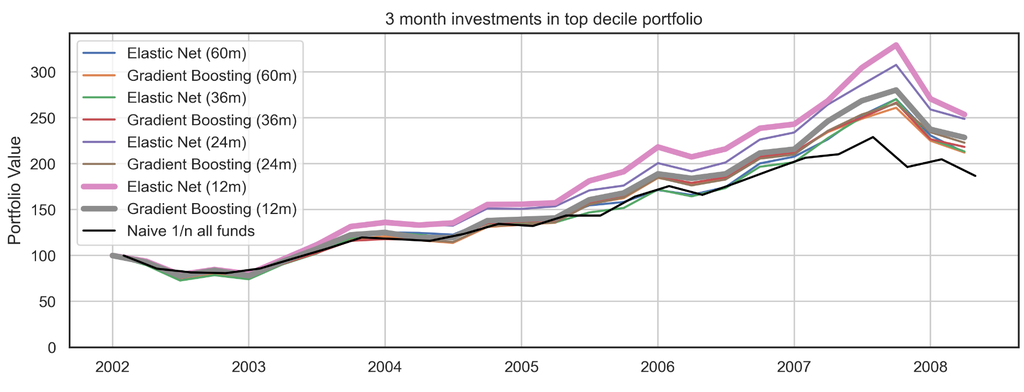

```python
Image("C:/Users/manue/switchdrive/Mutual Funds Project/Presentations/imgs/window_size_training.png", width = 1000)
```

The chart above displays portfolios which are held for 3 months and take into account differnt amount of past data. I evaluated top decil portfolios according to an elastic net and gradient boosting model. In both cases, the best models were formed by only considering 12 months of past information while the portfolio performance is lower for larger training sets. I cannot answer why this is the case but more recent data might be more important for prediction while more past data might just deteriorate the signal-to-noise ratio.

In line with the notation in Coqueret and Guida (2020), I use the following notation:

- $\Delta_h$ represents the holding period of the portfolio (= rebalancing frequency). I evalute the different holding periods: 3, 6, 12, 24 and 36 months.
- $\Delta_l$ represents the horizon over which the target is computed, e.g., 3 month cumulative returns oder 6 months. In my case, the holding period of the portfolio and the horizon of target variables is the same. That is, I use 3 month cumulative excess returns for a portfolio which is then hold for 3 months, however, one could use differnt approaches and train on 3 month returns but hold the portfolio for a different amount. Thus, in my case: $\Delta_h=\Delta_l$
- $\Delta_s$ represents the horizon of the desired training sample. In my case, this is 12 months.

The following is an illustration taken directly from Coqueret and Guida (2020).

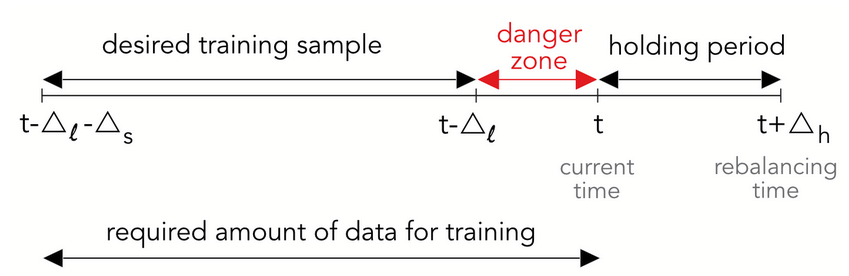

```python
Image("C:/Users/manue/switchdrive/Mutual Funds Project/Presentations/imgs/training_vs_holding_periods.png", width = 500)
```

Source of image: [Machine Learning for Factor Investing](http://www.mlfactor.com/chap_12.html), (Coqueret and Guida (2020))

Working with the 12 months of training prior to portfolio formation ($\Delta_s$) implies that I work with a rolling window aproach as opposed to an extending window which would grow the training sample over time. Yet, I use the years of 1980 until 1999 as a *buffer period* which is used to traing the models for the first portfolio construction at the beginning of 2000 as these earlier years exhibit less data per year as later years.

This procedure is illustrated in a simpliefied way in the next figure where the integer numbers represent the different rebalancing dates. The arrows for the training sample at each rebalancing dates are constant in length and do not grow as I use a rolling-window approach.

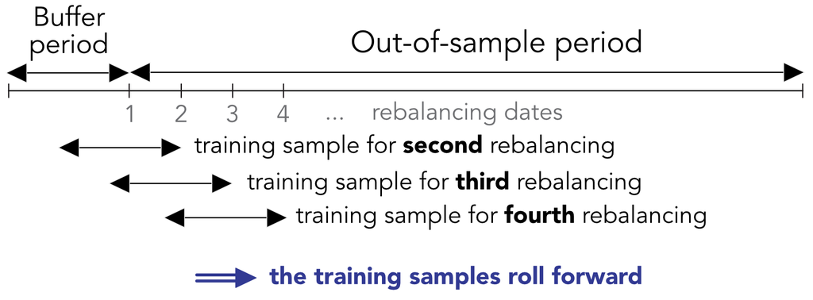

```python
Image("C:/Users/manue/switchdrive/Mutual Funds Project/Presentations/imgs/rollover_backtesting.png", width = 500)
```

Source of image: [Machine Learning for Factor Investing](http://www.mlfactor.com/chap_12.html), Coqueret and Guida (2020)

### 3.3 Machine Learning Model Choice

The choice of machine learning models was based on the related literature and what was considered sensible with regards to training time and computational resources. The following models are tested for predictive power:

- Elastic Net: This is the only linear model I consider. Regularization which is used in lasso and ridge regression is combined to prevent overfitting and focus on the most predictive features.
- Gradient Boosting: Gradient boosting still dominates in many machine learning competions on kaggle. It is a tree based model which proved to be powerful for financial forecasting according to related literature.
- Neural Network: I test a feedforwad neural network for predictive power. Neural networks prove to be powerful in domains outside of finance (speech, text, image classification etc.).

## Future Research Questions

# Bibliography

Berk, Jonathan B., and Jules H. Van Binsbergen, 2015, Measuring skill in the mutual fund industry, *Journal of Financial Economics* 118, 1–20.

Berk, Jonathan B., and Richard C. Green, 2004, Mutual Fund Flows and Performance in Rational Markets, *Journal of Political Economy* 112, 1269–1295.

Carhart, Mark M., 1997, On Persistence in Mutual Fund Performance, *The Journal of Finance* 52, 57–82.

Chu, Nghia, Binh Dao, Nga Pham, Huy Nguyen, and Hien Tran, 2022, Predicting Mutual Funds’ Performance using Deep Learning and Ensemble Techniques, (arXiv).

Coqueret, Guillaume, and Tony Guida, 2020, *Machine Learning for Factor Investing: R Version* (CRC Press).

DeMiguel, Victor, Javier Gil-Bazo, Francisco J. Nogales, and Andre A. P. Santos, 2021, Machine Learning and Fund Characteristics Help to Select Mutual Funds with Positive Alpha, . SSRN Scholarly PaperSSRN Scholarly Paper.

Fama, Eugene F., and Kenneth R. French, 2010, Luck versus Skill in the Cross-Section of Mutual Fund Returns, *The Journal of Finance* 65, 1915–1947.

Frazzini, Andrea, and Lasse Heje Pedersen, 2014, Betting against beta, *Journal of Financial Economics* 111, 1–25.

Goyal, Amit, and Sunil Wahal, 2015, Is Momentum an Echo?, *Journal of Financial and Quantitative Analysis* 50, 1237–1267.

Gu, Shihao, Bryan Kelly, and Dacheng Xiu, 2020, Empirical Asset Pricing via Machine Learning, *The Review of Financial Studies* 33, 2223–2273.

Hunter, David, Eugene Kandel, Shmuel Kandel, and Russ Wermers, 2014, Mutual fund performance evaluation with active peer benchmarks, *Journal of Financial Economics* 112, 1–29.

Jegadeesh, Narasimhan, and Sheridan Titman, 1993, Returns to Buying Winners and Selling Losers: Implications for Stock Market Efficiency, *The Journal of Finance* 48, 65–91.

Kacperczyk, Marcin, Stijn Van Nieuwerburgh, and Laura Veldkamp, 2014, Time-Varying Fund Manager Skill, *The Journal of Finance* 69, 1455–1484.

Kacperczyk, Marcin, Stijn Van Nieuwerburgh, and Laura Veldkamp, 2016, A Rational Theory of Mutual Funds’ Attention Allocation, *Econometrica* 84, 571–626.

Kaniel, Ron, Zihan Lin, Markus Pelger, and Stijn Van Nieuwerburgh, 2022, Machine-Learning the Skill of Mutual Fund Managers, . Working Paper. Working Paper Series (National Bureau of Economic Research).

Li, Bin, and Alberto G. Rossi, 2020, Selecting Mutual Funds from the Stocks They Hold: A Machine Learning Approach, *SSRN Electronic Journal*.

Newey, Whitney K., and Kenneth D. West, 1994, Automatic Lag Selection in Covariance Matrix Estimation, *The Review of Economic Studies* 61, 631–653.

Novy-Marx, Robert, 2012, Is momentum really momentum?, *Journal of Financial Economics* 103, 429–453.

Shah, Anoop D., Jonathan W. Bartlett, James Carpenter, Owen Nicholas, and Harry Hemingway, 2014, Comparison of Random Forest and Parametric Imputation Models for Imputing Missing Data Using MICE: A CALIBER Study, *American Journal of Epidemiology* 179, 764–774.

Wu, Wenbo, Jiaqi Chen, Zhibin (Ben) Yang, and Michael L. Tindall, 2021, A Cross-Sectional Machine Learning Approach for Hedge Fund Return Prediction and Selection, *Management Science* 67, 4577–4601.